# CCP4 (delayed boxes): analyses with 16 rows per person

# 1. Summary:

Present bias predicts less search overall, though no significant interactions with type of attribute

Beta predicts search and accuracy

# 2. Descriptive plots and descriptive statistics

## 2.1 DEEP histograms

### 2.1.1 Beta and Delta using Qi’s method

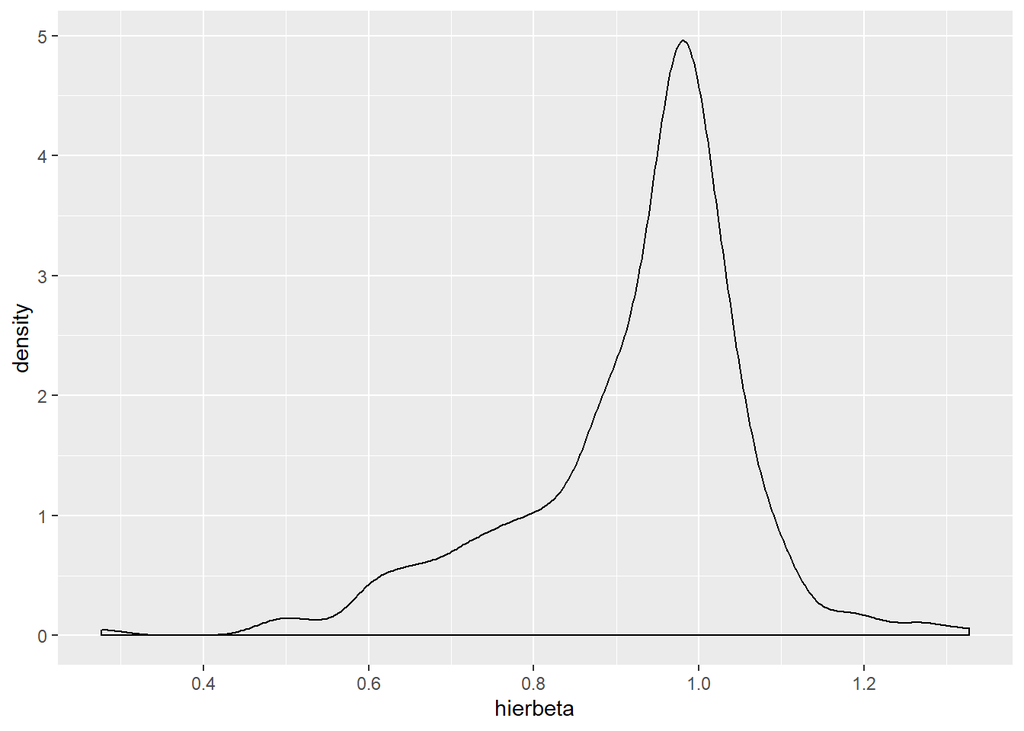

```r
ggplot(qual, aes(x=hierbeta)) +
  geom_density()
```

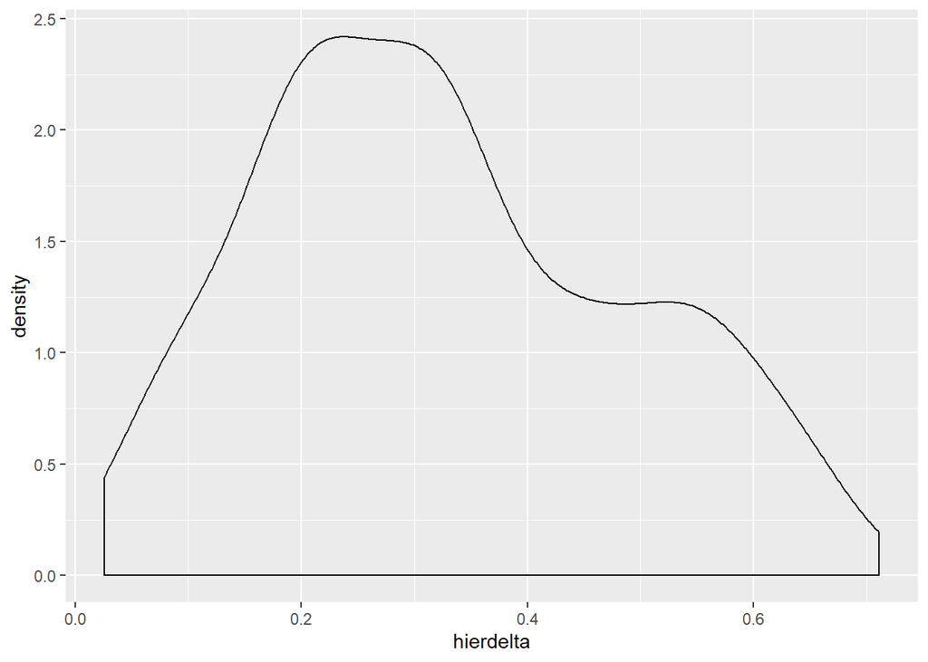

```r
ggplot(qual, aes(x=hierdelta)) +
  geom_density()
```

### 2.1.2 Beta and Delta using Dan’s method

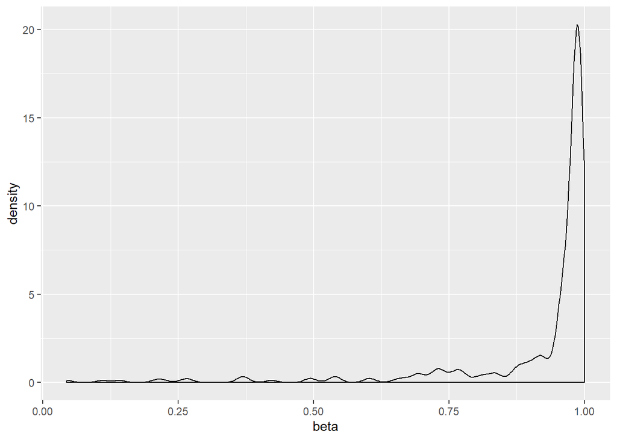

```r
ggplot(qual, aes(x=beta)) +
  geom_density()
```

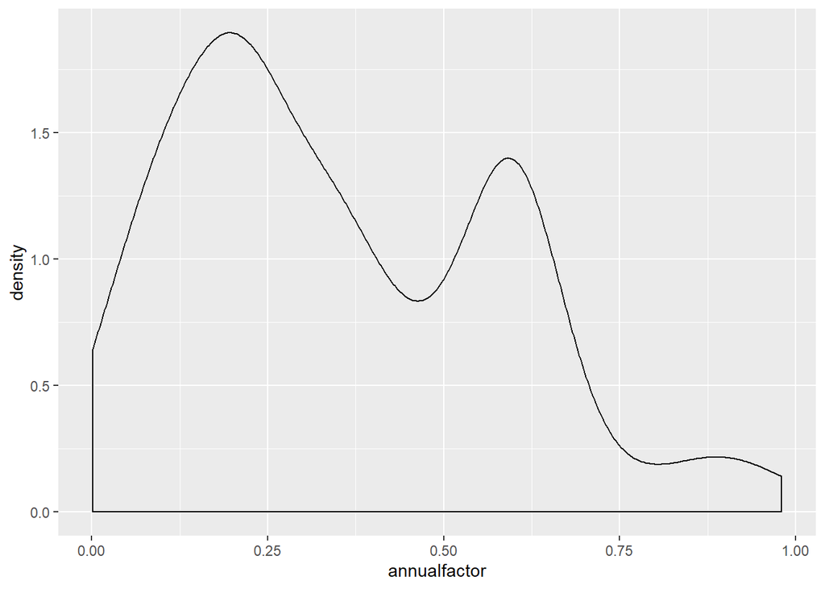

```r
ggplot(qual, aes(x=annualfactor)) +
  geom_density()
```

```r
#correlations are lower (better) using Dan's method.
cor(qual$beta, qual$annualfactor)
```

```
## [1] 0.1709817
```

```r
cor(qual$hierbeta,qual$hierdelta)
```

```
## [1] 0.2174455
```

## 2.2 Search histograms displaying skewness and reasons for using sqrt transformation

The rule I’ve been taught for skewness (which I also pre-registered, at least for CCP1) is if skewness is between -1 and +1, the variable can be left as is. If it is outside those, run a transformation to get it within those boundaries and as close to 0 as possible. Log-transformation results in a negative skew, which in CCP1 was less than -1 and is worse than the sqrt transformation in every study; square-root transformation does better (see stats below)

```r
skewness(cc$numopened,na.rm=TRUE)
```

```
## [1] 1.289282
```

```r
skewness(cc$sqrtnumopened,na.rm=TRUE)
```

```
## [1] 0.4389122
```

```r
skewness(cc$lognumopened,na.rm=TRUE)
```

```
## [1] -0.8167871
```

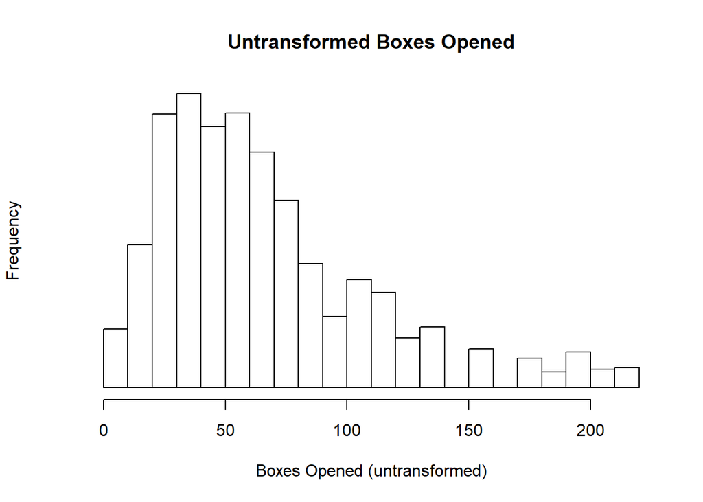

```r
hist(cc$numopened,main="Untransformed Boxes Opened",xlab="Boxes Opened (untransformed)",yaxt='n')
```

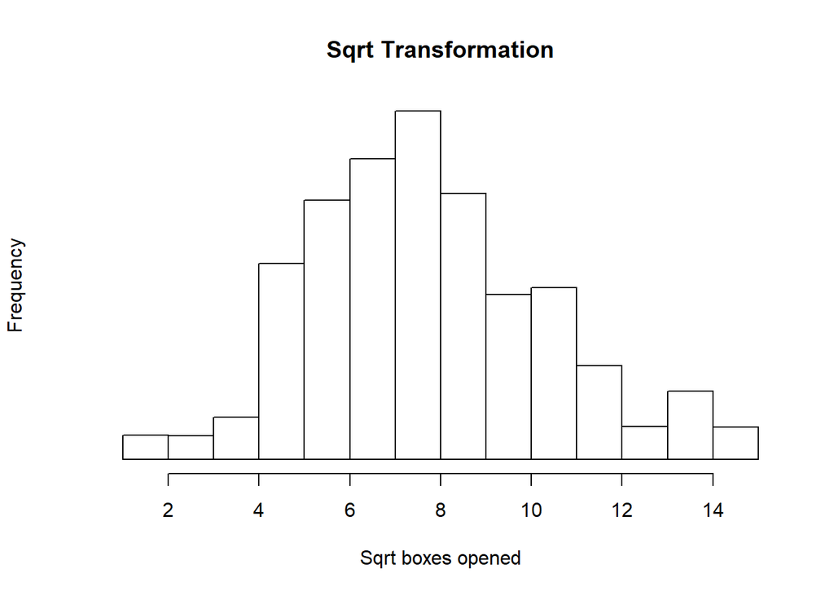

```r
hist(cc$sqrtnumopened,main="Sqrt Transformation",xlab="Sqrt boxes opened",yaxt='n')
```

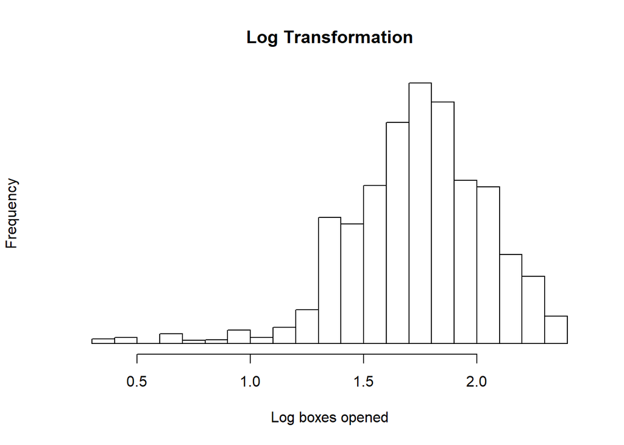

```r
hist(cc$lognumopened,main="Log Transformation",xlab="Log boxes opened",yaxt='n')
```

## 2.3 Search histograms and density plots by delay boxes condition

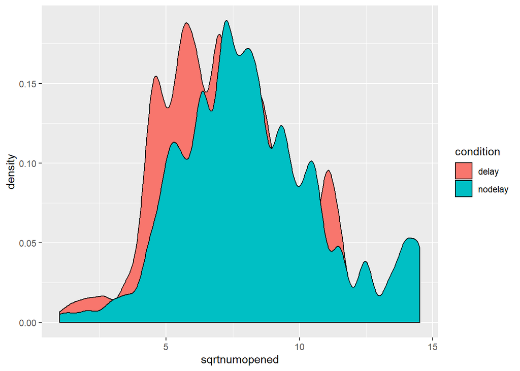

```r
ggplot(cc, aes(x=sqrtnumopened, fill = condition)) +
  geom_density()
```

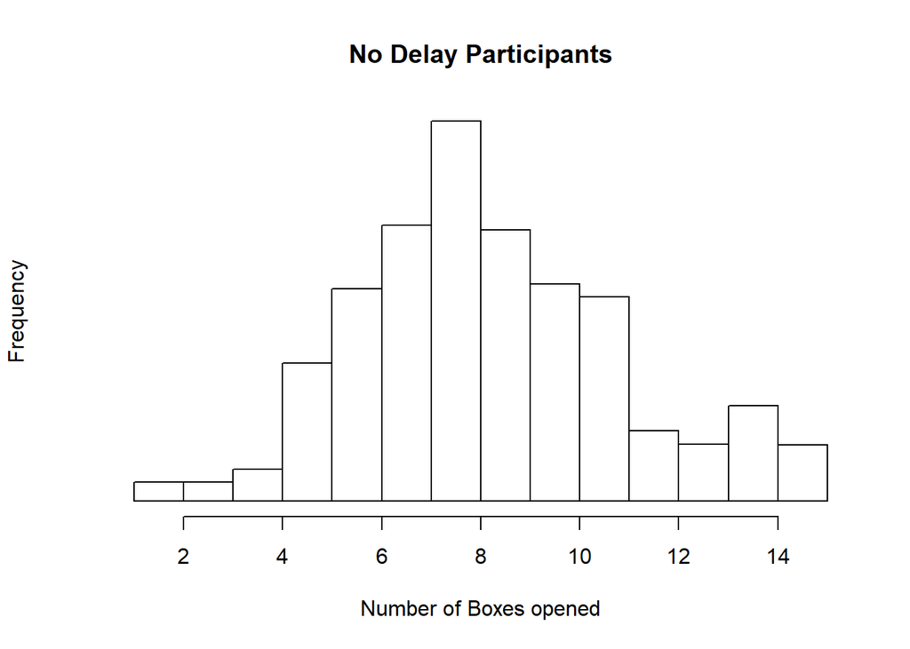

```r
###Search histograms as a function of condition
hist(ccnodelay$sqrtnumopened,main="No Delay Participants",xlab="Number of Boxes opened",yaxt='n')
```

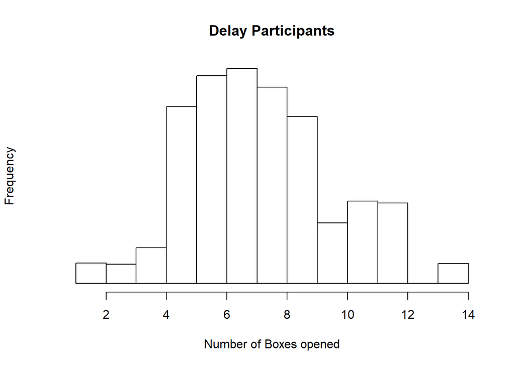

```r
hist(ccdelay$sqrtnumopened,breaks=10,main="Delay Participants",xlab="Number of Boxes opened",yaxt='n')
```

## 2.4 Choice accuracy overall, and by delayed boxes condition

```r
summary(f16$correct)
```

```
##    Min. 1st Qu.  Median    Mean 3rd Qu.    Max.
##  0.0000  0.0000  0.0000  0.4432  1.0000  1.0000
```

```r
summary(f16$correct[full$condition=="delay"],na.rm=TRUE)
```

```
##    Min. 1st Qu.  Median    Mean 3rd Qu.    Max.    NA's
##   0.000   0.000   0.000   0.461   1.000   1.000   11683
```

```r
summary(f16$correct[full$condition=="nodelay"],na.rm=TRUE)
```

```
##    Min. 1st Qu.  Median    Mean 3rd Qu.    Max.    NA's
##   0.000   0.000   0.000   0.428   1.000   1.000   18797
```

## 2.5 Descriptives of the new box openings measure.

**Fixations** is the number of times a given box was opened. 16 lines per participant, corresponding to the 16 boxes in the mlweb display.

Note. In this new format, skewness is actually best (lowest) for the log-transformation (3rd histogram and 3rd number in the skewness summary statistics below)

```r
skewness(f16$fixations,na.rm=TRUE)
```

```
## [1] 2.54335
```

```r
f16$sqrtfixations<-sqrt(f16$fixations)
skewness(f16$sqrtfixations,na.rm=TRUE)
```

```
## [1] 0.4572596
```

```r
f16$logfixations<-log10(f16$fixations+1)
skewness(f16$logfixations,na.rm=TRUE)
```

```
## [1] 0.02637204
```

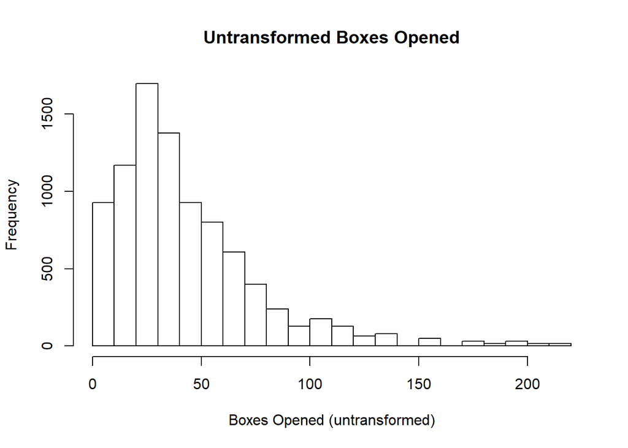

```r
hist(f16$numopened,main="Untransformed Boxes Opened",xlab="Boxes Opened (untransformed)")
```

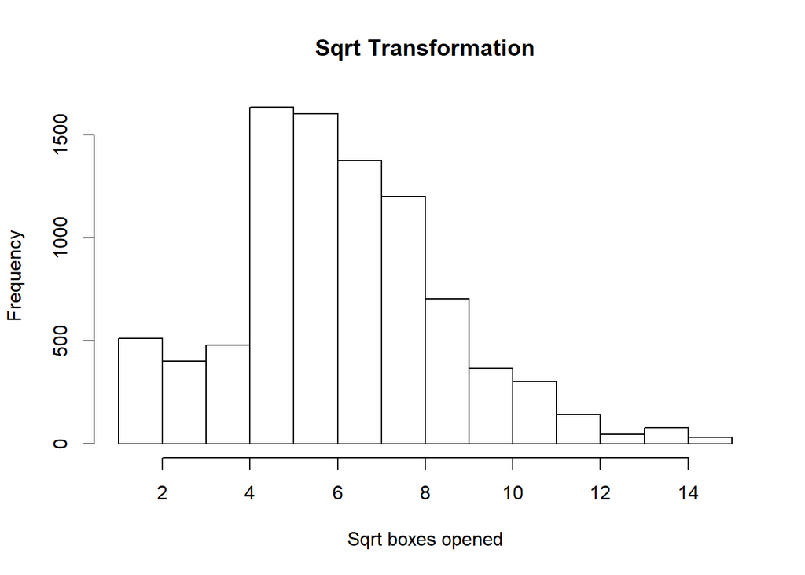

```r
hist(f16$sqrtnumopened,main="Sqrt Transformation",xlab="Sqrt boxes opened")
```

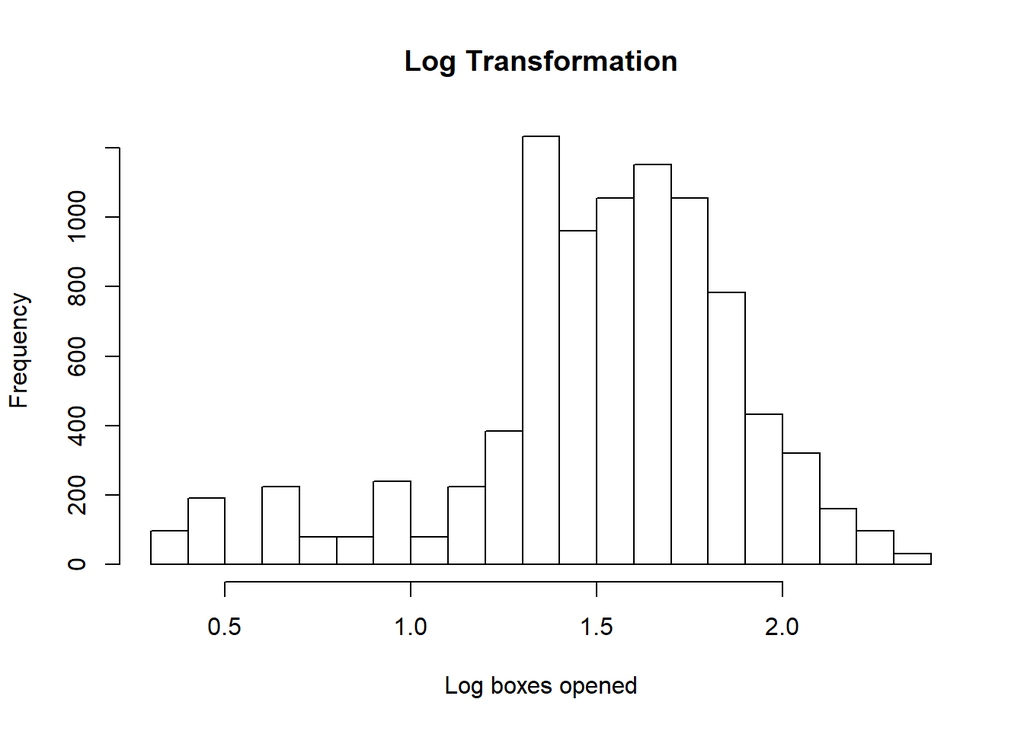

```r
hist(f16$lognumopened,main="Log Transformation",xlab="Log boxes opened")
```

```r
summary(f16$fixations)
```

```
##    Min. 1st Qu.  Median    Mean 3rd Qu.    Max.
##   0.000   1.000   3.000   4.317   6.000  50.000
```

# 3. New Inferential Analyses

## 3.1. Model below predicts number of fixations on a box from attribute of the box, beta, delta, and interactions with beta and delta.

Note. It now converges even with this complex model, thanks to the optimizer… line of code.

```r
f16$hierbeta.c<-f16$hierbeta-mean(f16$hierbeta,na.rm=TRUE)
f16$hierdelta.c<-f16$hierdelta-mean(f16$hierdelta,na.rm=TRUE)
f16$standard.c<-f16$dummystd-.5
f16$intro.c<-f16$dummyintro-.5
f16$period.c<-f16$dummyperiod-.5
f16$annualfee.c<-f16$dummyannual-.5

m6<-glmer(fixations~hierbeta.c*standard.c+hierbeta.c*intro.c+hierbeta.c*period.c+hierdelta.c*standard.c+hierdelta.c*intro.c+hierdelta.c*period.c+(1|ipaddress),data=f16,family=poisson,control=glmerControl(optimizer="bobyqa",optCtrl=list(maxfun=2e5)))
summary(m6)
```

```
## Generalized linear mixed model fit by maximum likelihood (Laplace
##   Approximation) [glmerMod]
##  Family: poisson  ( log )
## Formula: fixations ~ hierbeta.c * standard.c + hierbeta.c * intro.c +
##     hierbeta.c * period.c + hierdelta.c * standard.c + hierdelta.c *
##     intro.c + hierdelta.c * period.c + (1 | ipaddress)
##    Data: f16
## Control:
## glmerControl(optimizer = "bobyqa", optCtrl = list(maxfun = 2e+05))
##
##      AIC      BIC   logLik deviance df.resid
##  40172.6  40264.8 -20073.3  40146.6     8867
##
## Scaled residuals:
##     Min      1Q  Median      3Q     Max
## -3.6211 -0.8374 -0.2104  0.6443 14.6779
##
## Random effects:
##  Groups    Name        Variance Std.Dev.
##  ipaddress (Intercept) 0.6346   0.7966
## Number of obs: 8880, groups:  ipaddress, 298
##
## Fixed effects:
##                         Estimate Std. Error z value Pr(>|z|)
## (Intercept)             0.958206   0.047682  20.096  < 2e-16 ***
## hierbeta.c              1.869510   0.368639   5.071 3.95e-07 ***
## standard.c             -0.374954   0.014850 -25.250  < 2e-16 ***
## intro.c                -0.338863   0.014701 -23.051  < 2e-16 ***
## period.c               -0.073247   0.013668  -5.359 8.37e-08 ***
## hierdelta.c             0.383160   0.301346   1.271   0.2036
## hierbeta.c:standard.c  -0.018190   0.127109  -0.143   0.8862
## hierbeta.c:intro.c     -0.008265   0.125751  -0.066   0.9476
## hierbeta.c:period.c     0.003237   0.116899   0.028   0.9779
## standard.c:hierdelta.c  0.004881   0.095639   0.051   0.9593
## intro.c:hierdelta.c     0.099242   0.094518   1.050   0.2937
## period.c:hierdelta.c    0.169305   0.087798   1.928   0.0538 .
## ---
## Signif. codes:  0 '***' 0.001 '**' 0.01 '*' 0.05 '.' 0.1 ' ' 1
##
## Correlation of Fixed Effects:
```

[output cut: 9 more lines]

```
## stndrd.c:h. -0.009 -0.054 -0.055 -0.022 -0.024  0.158 -0.315    -0.130
## intr.c:hrd. -0.010 -0.053 -0.023 -0.063 -0.024  0.156 -0.130    -0.315
## prd.c:hrdl. -0.010 -0.050 -0.024 -0.024 -0.067  0.145 -0.140    -0.141
##             hrbt.c:p. stn.:. int.:.
## hierbeta.c
## standard.c
## intro.c
## period.c
## hierdelta.c
## hrbt.c:stn.
## hrbt.c:ntr.
## hrbt.c:prd.
## stndrd.c:h. -0.139
## intr.c:hrd. -0.141     0.412
## prd.c:hrdl. -0.316     0.444  0.449
```

```r
#I'm not sure why this didn't work; interact_plot has worked for me in the past. Perhaps I need to update package.

#library(jtools)

#m9<-glmer(fixations~hierdelta*period.c+(1|ipaddress),data=f16,family=poisson,control=glmerControl(optimizer="bobyqa",optCtrl=list(maxfun=2e5)))

#interact_plot(m9, hierdelta, period.c)
```

## 3.3: Plot of the relationship between beta and search for each of the four attributes.

```r
f16$attbox<-as.factor(f16$attbox)

m7<-glmer(fixations~hierbeta*attbox+(1|ipaddress),data=f16,family=poisson,control=glmerControl(optimizer="bobyqa",optCtrl=list(maxfun=2e5)))
summary(m7)
```

```
## Generalized linear mixed model fit by maximum likelihood (Laplace
##   Approximation) [glmerMod]
##  Family: poisson  ( log )
## Formula: fixations ~ hierbeta * attbox + (1 | ipaddress)
##    Data: f16
## Control:
## glmerControl(optimizer = "bobyqa", optCtrl = list(maxfun = 2e+05))
##
##      AIC      BIC   logLik deviance df.resid
##  40170.5  40234.3 -20076.3  40152.5     8871
##
## Scaled residuals:
##     Min      1Q  Median      3Q     Max
## -3.6444 -0.8435 -0.2159  0.6427 14.5612
##
## Random effects:
##  Groups    Name        Variance Std.Dev.
##  ipaddress (Intercept) 0.6375   0.7984
## Number of obs: 8880, groups:  ipaddress, 298
##
## Fixed effects:
##                    Estimate Std. Error z value Pr(>|z|)
## (Intercept)        -0.81161    0.34067  -2.382  0.01720 *
## hierbeta            1.92153    0.36276   5.297 1.18e-07 ***
## attboxAPR           0.35991    0.11578   3.109  0.00188 **
## attboxiAP          -0.00911    0.12497  -0.073  0.94189
## attboxiPe           0.21911    0.11765   1.862  0.06256 .
## hierbeta:attboxAPR  0.01613    0.12063   0.134  0.89363
## hierbeta:attboxiAP  0.04958    0.13018   0.381  0.70327
## hierbeta:attboxiPe  0.09067    0.12253   0.740  0.45931
## ---
## Signif. codes:  0 '***' 0.001 '**' 0.01 '*' 0.05 '.' 0.1 ' ' 1
##
## Correlation of Fixed Effects:
##             (Intr) hierbt attAPR attbAP attbxP hr:APR hrb:AP
## hierbeta    -0.990
## attboxAPR   -0.201  0.195
## attboxiAP   -0.186  0.181  0.549
## attboxiPe   -0.197  0.192  0.583  0.540
## hrbt:ttbAPR  0.200 -0.197 -0.992 -0.545 -0.579
## hrbt:ttbxAP  0.185 -0.182 -0.545 -0.992 -0.536  0.549
## hirbt:ttbxP  0.196 -0.193 -0.579 -0.536 -0.992  0.583  0.541
```

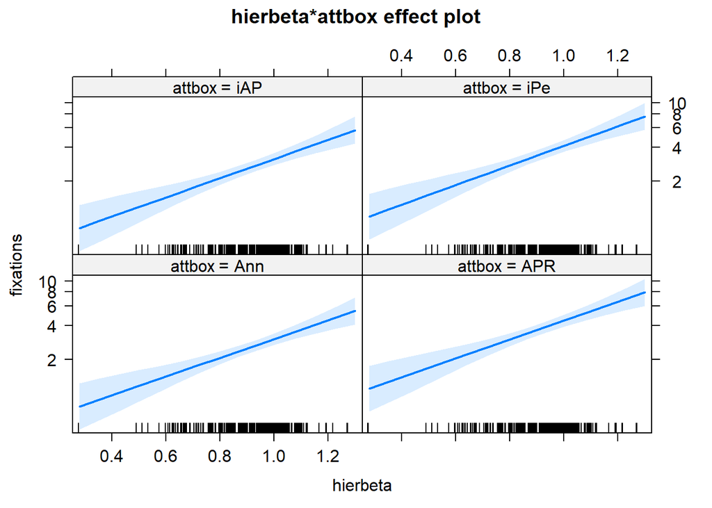

```r
plot(Effect(c("hierbeta", "attbox"), m7))
```

## 3.4 Plot of the relationship between delta and search for each of the four attributes.

```r
m8<-glmer(fixations~hierdelta*attbox+(1|ipaddress),data=f16,family=poisson,control=glmerControl(optimizer="bobyqa",optCtrl=list(maxfun=2e5)))
summary(m8)
```

```
## Generalized linear mixed model fit by maximum likelihood (Laplace
##   Approximation) [glmerMod]
##  Family: poisson  ( log )
## Formula: fixations ~ hierdelta * attbox + (1 | ipaddress)
##    Data: f16
## Control:
## glmerControl(optimizer = "bobyqa", optCtrl = list(maxfun = 2e+05))
##
##      AIC      BIC   logLik deviance df.resid
##  40190.7  40254.6 -20086.4  40172.7     8871
##
## Scaled residuals:
##     Min      1Q  Median      3Q     Max
## -3.6219 -0.8397 -0.2072  0.6464 14.6509
##
## Random effects:
##  Groups    Name        Variance Std.Dev.
##  ipaddress (Intercept) 0.6905   0.831
## Number of obs: 8880, groups:  ipaddress, 298
##
## Fixed effects:
##                       Estimate Std. Error z value Pr(>|z|)
## (Intercept)          0.7796190  0.1119743   6.962 3.34e-12 ***
## hierdelta            0.5869555  0.3070984   1.911   0.0560 .
## attboxAPR            0.3754621  0.0346212  10.845  < 2e-16 ***
## attboxiAP            0.0045297  0.0374349   0.121   0.9037
## attboxiPe            0.2464648  0.0352601   6.990 2.75e-12 ***
## hierdelta:attboxAPR -0.0005543  0.0907923  -0.006   0.9951
## hierdelta:attboxiAP  0.0967553  0.0978750   0.989   0.3229
## hierdelta:attboxiPe  0.1695739  0.0920458   1.842   0.0654 .
## ---
## Signif. codes:  0 '***' 0.001 '**' 0.01 '*' 0.05 '.' 0.1 ' ' 1
##
## Correlation of Fixed Effects:
##             (Intr) hirdlt attAPR attbAP attbxP hr:APR hrd:AP
## hierdelta   -0.896
## attboxAPR   -0.183  0.159
## attboxiAP   -0.169  0.147  0.548
## attboxiPe   -0.180  0.156  0.582  0.538
## hrdlt:ttAPR  0.166 -0.175 -0.907 -0.497 -0.528
## hrdlt:ttbAP  0.154 -0.162 -0.499 -0.907 -0.490  0.550
## hrdlt:ttbxP  0.164 -0.173 -0.530 -0.490 -0.908  0.585  0.542
```

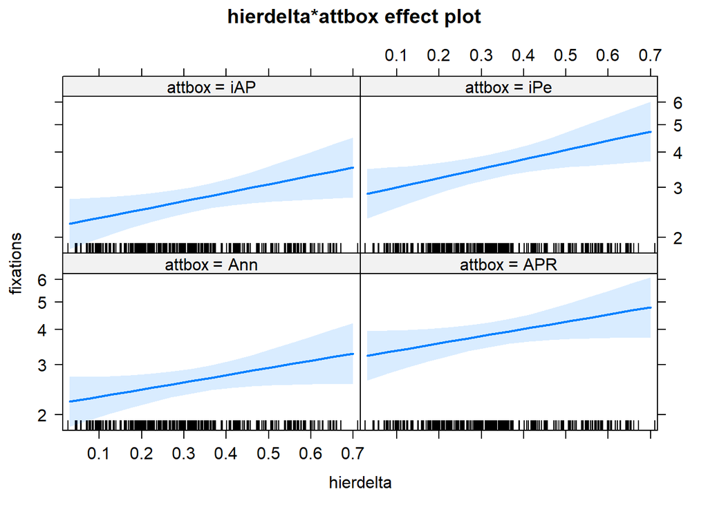

```r
plot(Effect(c("hierdelta", "attbox"), m8))
```

# 4. Old inferential analyses

## 4.1 Present bias is associated with less search (using data that is 1 trial per line)

```r
#should be similar to the overall fixation results from before

m1a<-lmer(sqrtnumopened~hierbeta+hierdelta+(1|ipaddress),data=f16)
summary(m1a)
```

```
## Linear mixed model fit by REML. t-tests use Satterthwaite's method [
## lmerModLmerTest]
## Formula: sqrtnumopened ~ hierbeta + hierdelta + (1 | ipaddress)
##    Data: f16
##
## REML criterion at convergence: 26014.1
##
## Scaled residuals:
##     Min      1Q  Median      3Q     Max
## -4.2794 -0.5186 -0.0048  0.5134  5.4589
##
## Random effects:
##  Groups    Name        Variance Std.Dev.
##  ipaddress (Intercept) 4.8313   2.1980
##  Residual              0.9265   0.9626
## Number of obs: 8880, groups:  ipaddress, 298
##
## Fixed effects:
##             Estimate Std. Error       df t value Pr(>|t|)
## (Intercept)   1.8591     0.8912 295.1863   2.086   0.0378 *
## hierbeta      4.2810     0.9717 295.2137   4.405 1.48e-05 ***
## hierdelta     0.9547     0.8088 294.9020   1.180   0.2388
## ---
## Signif. codes:  0 '***' 0.001 '**' 0.01 '*' 0.05 '.' 0.1 ' ' 1
##
## Correlation of Fixed Effects:
##           (Intr) hierbt
## hierbeta  -0.947
## hierdelta -0.078 -0.215
```

```r
m2<-lmer(logfixations~hierbeta+hierdelta+(1|ipaddress),data=f16)
summary(m2)
```

```
## Linear mixed model fit by REML. t-tests use Satterthwaite's method [
## lmerModLmerTest]
## Formula: logfixations ~ hierbeta + hierdelta + (1 | ipaddress)
##    Data: f16
##
## REML criterion at convergence: -512.6
##
## Scaled residuals:
##     Min      1Q  Median      3Q     Max
## -4.1407 -0.6329  0.0126  0.6918  5.0419
##
## Random effects:
##  Groups    Name        Variance Std.Dev.
##  ipaddress (Intercept) 0.05648  0.2376
##  Residual              0.04904  0.2214
## Number of obs: 8880, groups:  ipaddress, 298
##
## Fixed effects:
##              Estimate Std. Error        df t value Pr(>|t|)
## (Intercept)   0.04958    0.09762 295.78892   0.508    0.612
## hierbeta      0.54962    0.10645 295.91106   5.163 4.46e-07 ***
## hierdelta     0.12318    0.08852 294.56503   1.392    0.165
## ---
## Signif. codes:  0 '***' 0.001 '**' 0.01 '*' 0.05 '.' 0.1 ' ' 1
##
## Correlation of Fixed Effects:
##           (Intr) hierbt
## hierbeta  -0.947
## hierdelta -0.077 -0.216
```

```r
m3<-glmer(fixations~hierbeta+hierdelta+(1|ipaddress),data=f16,family=poisson,control=glmerControl(optimizer="bobyqa",optCtrl=list(maxfun=2e5)))
summary(m3)
```

```
## Generalized linear mixed model fit by maximum likelihood (Laplace
##   Approximation) [glmerMod]
##  Family: poisson  ( log )
## Formula: fixations ~ hierbeta + hierdelta + (1 | ipaddress)
##    Data: f16
## Control:
## glmerControl(optimizer = "bobyqa", optCtrl = list(maxfun = 2e+05))
##
##      AIC      BIC   logLik deviance df.resid
##  41172.3  41200.7 -20582.2  41164.3     8876
##
## Scaled residuals:
##     Min      1Q  Median      3Q     Max
## -3.2861 -0.8502 -0.2418  0.6703 16.4088
##
## Random effects:
##  Groups    Name        Variance Std.Dev.
##  ipaddress (Intercept) 0.6346   0.7966
## Number of obs: 8880, groups:  ipaddress, 298
##
## Fixed effects:
##             Estimate Std. Error z value Pr(>|z|)
## (Intercept)  -0.6808     0.3295  -2.066   0.0388 *
## hierbeta      1.8766     0.3594   5.221 1.78e-07 ***
## hierdelta     0.3161     0.2951   1.071   0.2840
## ---
## Signif. codes:  0 '***' 0.001 '**' 0.01 '*' 0.05 '.' 0.1 ' ' 1
##
## Correlation of Fixed Effects:
##           (Intr) hierbt
## hierbeta  -0.948
## hierdelta -0.068 -0.221
```

##4.2 More present bias predicts lower accuracy

```r
m1b<-lmer(correct~hierbeta+hierdelta+(1|ipaddress),data=f16)
summary(m1b)
```

```
## Linear mixed model fit by REML. t-tests use Satterthwaite's method [
## lmerModLmerTest]
## Formula: correct ~ hierbeta + hierdelta + (1 | ipaddress)
##    Data: f16
##
## REML criterion at convergence: 2698.6
##
## Scaled residuals:
##     Min      1Q  Median      3Q     Max
## -2.8591 -0.0214 -0.0163  0.0245  3.1813
##
## Random effects:
##  Groups    Name        Variance Std.Dev.
##  ipaddress (Intercept) 0.18235  0.4270
##  Residual              0.06852  0.2618
## Number of obs: 8880, groups:  ipaddress, 298
##
## Fixed effects:
##              Estimate Std. Error        df t value Pr(>|t|)
## (Intercept)   0.02087    0.17377 295.36341   0.120   0.9045
## hierbeta      0.41463    0.18947 295.41681   2.188   0.0294 *
## hierdelta     0.09195    0.15766 294.81391   0.583   0.5602
## ---
## Signif. codes:  0 '***' 0.001 '**' 0.01 '*' 0.05 '.' 0.1 ' ' 1
##
## Correlation of Fixed Effects:
##           (Intr) hierbt
## hierbeta  -0.947
## hierdelta -0.077 -0.216
```

```r
m1b<-glmer(correct~hierbeta+hierdelta+(1|ipaddress),family=binomial,data=f16,control=glmerControl(optimizer="bobyqa",optCtrl=list(maxfun=2e5)))
summary(m1b)
```

```
## Generalized linear mixed model fit by maximum likelihood (Laplace
##   Approximation) [glmerMod]
##  Family: binomial  ( logit )
## Formula: correct ~ hierbeta + hierdelta + (1 | ipaddress)
##    Data: f16
## Control:
## glmerControl(optimizer = "bobyqa", optCtrl = list(maxfun = 2e+05))
##
##      AIC      BIC   logLik deviance df.resid
##   4257.8   4286.2  -2124.9   4249.8     8876
##
## Scaled residuals:
##      Min       1Q   Median       3Q      Max
## -1.72987 -0.00453 -0.00342  0.03747  2.23821
##
## Random effects:
##  Groups    Name        Variance Std.Dev.
##  ipaddress (Intercept) 384.5    19.61
## Number of obs: 8880, groups:  ipaddress, 298
##
## Fixed effects:
##             Estimate Std. Error z value Pr(>|z|)
## (Intercept)  -13.296      2.951  -4.506 6.61e-06 ***
## hierbeta       2.574      3.191   0.807     0.42
## hierdelta      0.429      2.621   0.164     0.87
## ---
## Signif. codes:  0 '***' 0.001 '**' 0.01 '*' 0.05 '.' 0.1 ' ' 1
##
## Correlation of Fixed Effects:
##           (Intr) hierbt
## hierbeta  -0.939
## hierdelta -0.116 -0.166
```

## 4.3 Mediation model: present bias–>less search–>lower accuracy

We get a significant indirect effect, as in previous studies. I’m not copying it here because it takes an hour or more to run and slows everything down.

# 5. Robustness

## 5.1 Pre-registered robustness tests:

### 5.1.1 Exclude those who don’t own credit card. Effect of beta on search remains.

```r
f16$owncard<-NA
f16$owncard[f16$owncreditcard==1]<-1
f16$owncard[f16$owncreditcard==2]<-0

f16owners<-f16[!(f16$owncard==0), ]

#boxes opened
m3<-glmer(fixations~hierbeta+hierdelta+(1|ipaddress),data=f16owners,family=poisson,control=glmerControl(optimizer="bobyqa",optCtrl=list(maxfun=2e5)))
summary(m3)
```

```
## Generalized linear mixed model fit by maximum likelihood (Laplace
##   Approximation) [glmerMod]
##  Family: poisson  ( log )
## Formula: fixations ~ hierbeta + hierdelta + (1 | ipaddress)
##    Data: f16owners
## Control:
## glmerControl(optimizer = "bobyqa", optCtrl = list(maxfun = 2e+05))
##
##      AIC      BIC   logLik deviance df.resid
##  34922.4  34950.1 -17457.2  34914.4     7404
##
## Scaled residuals:
##     Min      1Q  Median      3Q     Max
## -3.2857 -0.8575 -0.2397  0.6733 16.4104
##
## Random effects:
##  Groups    Name        Variance Std.Dev.
##  ipaddress (Intercept) 0.5871   0.7662
## Number of obs: 7408, groups:  ipaddress, 247
##
## Fixed effects:
##             Estimate Std. Error z value Pr(>|z|)
## (Intercept)  -0.6628     0.3557  -1.864   0.0624 .
## hierbeta      1.8818     0.3829   4.915 8.87e-07 ***
## hierdelta     0.3745     0.3095   1.210   0.2263
## ---
## Signif. codes:  0 '***' 0.001 '**' 0.01 '*' 0.05 '.' 0.1 ' ' 1
##
## Correlation of Fixed Effects:
##           (Intr) hierbt
## hierbeta  -0.951
## hierdelta -0.089 -0.192
```

```r
#searchtime
m3a<-lmer(logtime~hierbeta+hierdelta+(1|ipaddress),data=f16owners)
summary(m3a)
```

```
## Linear mixed model fit by REML. t-tests use Satterthwaite's method [
## lmerModLmerTest]
## Formula: logtime ~ hierbeta + hierdelta + (1 | ipaddress)
##    Data: f16owners
##
## REML criterion at convergence: -3421.4
##
## Scaled residuals:
##     Min      1Q  Median      3Q     Max
## -3.0559 -0.4549 -0.0052  0.4524  3.7859
##
## Random effects:
##  Groups    Name        Variance Std.Dev.
##  ipaddress (Intercept) 0.21532  0.4640
##  Residual              0.03088  0.1757
## Number of obs: 7408, groups:  ipaddress, 247
##
## Fixed effects:
##             Estimate Std. Error       df t value Pr(>|t|)
## (Intercept)   0.8496     0.2099 244.3259   4.048 6.94e-05 ***
## hierbeta      0.9546     0.2257 244.3473   4.230 3.31e-05 ***
## hierdelta     0.2684     0.1859 244.1446   1.444     0.15
## ---
## Signif. codes:  0 '***' 0.001 '**' 0.01 '*' 0.05 '.' 0.1 ' ' 1
##
## Correlation of Fixed Effects:
##           (Intr) hierbt
## hierbeta  -0.949
## hierdelta -0.102 -0.184
```

### 5.1.2 Exclude search time outliers (greater than 300 seconds)

```r
f16nooutliers<-f16[!(f16$searchtime>300), ]

#boxes opened
m3<-glmer(fixations~hierbeta+hierdelta+(1|ipaddress),data=f16nooutliers,family=poisson,control=glmerControl(optimizer="bobyqa",optCtrl=list(maxfun=2e5)))
summary(m3)
```

```
## Generalized linear mixed model fit by maximum likelihood (Laplace
##   Approximation) [glmerMod]
##  Family: poisson  ( log )
## Formula: fixations ~ hierbeta + hierdelta + (1 | ipaddress)
##    Data: f16nooutliers
## Control:
## glmerControl(optimizer = "bobyqa", optCtrl = list(maxfun = 2e+05))
##
##      AIC      BIC   logLik deviance df.resid
##  33275.6  33303.4 -16633.8  33267.6     7644
##
## Scaled residuals:
##     Min      1Q  Median      3Q     Max
## -3.2845 -0.8135 -0.2408  0.6505 16.4125
##
## Random effects:
##  Groups    Name        Variance Std.Dev.
##  ipaddress (Intercept) 0.5902   0.7683
## Number of obs: 7648, groups:  ipaddress, 273
##
## Fixed effects:
##             Estimate Std. Error z value Pr(>|z|)
## (Intercept)  -0.5689     0.3287  -1.731   0.0835 .
## hierbeta      1.6664     0.3582   4.652 3.29e-06 ***
## hierdelta     0.3057     0.2948   1.037   0.2996
## ---
## Signif. codes:  0 '***' 0.001 '**' 0.01 '*' 0.05 '.' 0.1 ' ' 1
##
## Correlation of Fixed Effects:
##           (Intr) hierbt
## hierbeta  -0.948
## hierdelta -0.091 -0.197
```

```r
#searchtime
m3a<-lmer(logtime~hierbeta+hierdelta+(1|ipaddress),data=f16nooutliers)
summary(m3a)
```

```
## Linear mixed model fit by REML. t-tests use Satterthwaite's method [
## lmerModLmerTest]
## Formula: logtime ~ hierbeta + hierdelta + (1 | ipaddress)
##    Data: f16nooutliers
##
## REML criterion at convergence: -4142.4
##
## Scaled residuals:
##     Min      1Q  Median      3Q     Max
## -3.1827 -0.4627  0.0075  0.4561  3.9427
##
## Random effects:
##  Groups    Name        Variance Std.Dev.
##  ipaddress (Intercept) 0.15741  0.3968
##  Residual              0.02848  0.1687
## Number of obs: 7648, groups:  ipaddress, 273
##
## Fixed effects:
##             Estimate Std. Error       df t value Pr(>|t|)
## (Intercept)   1.0711     0.1652 269.7864   6.482 4.28e-10 ***
## hierbeta      0.6324     0.1800 269.7811   3.514 0.000518 ***
## hierdelta     0.1297     0.1505 269.5821   0.862 0.389518
## ---
## Signif. codes:  0 '***' 0.001 '**' 0.01 '*' 0.05 '.' 0.1 ' ' 1
##
## Correlation of Fixed Effects:
##           (Intr) hierbt
## hierbeta  -0.947
## hierdelta -0.101 -0.192
```

## 5.2 Other robustness tests (most of which I did in CCP1)

```r
#boxes opened
m3<-glmer(fixations~finliteracy+hierbeta+hierdelta+(1|ipaddress),data=f16,family=poisson,control=glmerControl(optimizer="bobyqa",optCtrl=list(maxfun=2e5)))
summary(m3)
```

```
## Generalized linear mixed model fit by maximum likelihood (Laplace
##   Approximation) [glmerMod]
##  Family: poisson  ( log )
## Formula: fixations ~ finliteracy + hierbeta + hierdelta + (1 | ipaddress)
##    Data: f16
## Control:
## glmerControl(optimizer = "bobyqa", optCtrl = list(maxfun = 2e+05))
##
##      AIC      BIC   logLik deviance df.resid
##  41144.5  41180.0 -20567.2  41134.5     8875
##
## Scaled residuals:
##     Min      1Q  Median      3Q     Max
## -3.2864 -0.8511 -0.2442  0.6665 16.4141
##
## Random effects:
##  Groups    Name        Variance Std.Dev.
##  ipaddress (Intercept) 0.5726   0.7567
## Number of obs: 8880, groups:  ipaddress, 298
##
## Fixed effects:
##             Estimate Std. Error z value Pr(>|z|)
## (Intercept) -0.61883    0.31372  -1.973 0.048546 *
## finliteracy  1.06062    0.18961   5.594 2.22e-08 ***
## hierbeta     1.20017    0.36159   3.319 0.000903 ***
## hierdelta   -0.05513    0.28869  -0.191 0.848553
## ---
## Signif. codes:  0 '***' 0.001 '**' 0.01 '*' 0.05 '.' 0.1 ' ' 1
##
## Correlation of Fixed Effects:
##             (Intr) fnltrc hierbt
## finliteracy  0.024
## hierbeta    -0.904 -0.325
## hierdelta   -0.072 -0.230 -0.128
```

```r
#searchtime
m3a<-lmer(logtime~hierbeta+hierdelta+(1|ipaddress),data=f16)
summary(m3a)
```

```
## Linear mixed model fit by REML. t-tests use Satterthwaite's method [
## lmerModLmerTest]
## Formula: logtime ~ hierbeta + hierdelta + (1 | ipaddress)
##    Data: f16
##
## REML criterion at convergence: -4232.4
##
## Scaled residuals:
##     Min      1Q  Median      3Q     Max
## -3.0840 -0.4805 -0.0060  0.4949  3.8210
##
## Random effects:
##  Groups    Name        Variance Std.Dev.
##  ipaddress (Intercept) 0.22957  0.4791
##  Residual              0.03032  0.1741
## Number of obs: 8880, groups:  ipaddress, 298
##
## Fixed effects:
##             Estimate Std. Error       df t value Pr(>|t|)
## (Intercept)   0.8596     0.1940 295.2631   4.430 1.33e-05 ***
## hierbeta      0.9480     0.2116 295.2820   4.481 1.07e-05 ***
## hierdelta     0.1827     0.1761 295.0667   1.038      0.3
## ---
## Signif. codes:  0 '***' 0.001 '**' 0.01 '*' 0.05 '.' 0.1 ' ' 1
##
## Correlation of Fixed Effects:
##           (Intr) hierbt
## hierbeta  -0.947
## hierdelta -0.078 -0.215
```

### 5.2.2 Add CRT and numeracy as additional covariates (we did not measure these in CCP1)

```r
#boxes opened
m3<-glmer(fixations~finliteracy+crt+numeracy+hierbeta+hierdelta+(1|ipaddress),data=f16,family=poisson,control=glmerControl(optimizer="bobyqa",optCtrl=list(maxfun=2e5)))
summary(m3)
```

```
## Generalized linear mixed model fit by maximum likelihood (Laplace
##   Approximation) [glmerMod]
##  Family: poisson  ( log )
## Formula:
## fixations ~ finliteracy + crt + numeracy + hierbeta + hierdelta +
##     (1 | ipaddress)
##    Data: f16
## Control:
## glmerControl(optimizer = "bobyqa", optCtrl = list(maxfun = 2e+05))
##
##      AIC      BIC   logLik deviance df.resid
##  41128.5  41178.1 -20557.2  41114.5     8873
##
## Scaled residuals:
##     Min      1Q  Median      3Q     Max
## -3.2865 -0.8493 -0.2360  0.6728 16.4284
##
## Random effects:
##  Groups    Name        Variance Std.Dev.
##  ipaddress (Intercept) 0.5352   0.7316
## Number of obs: 8880, groups:  ipaddress, 298
##
## Fixed effects:
##             Estimate Std. Error z value Pr(>|z|)
## (Intercept) -0.55253    0.30553  -1.808 0.070543 .
## finliteracy  0.66210    0.20530   3.225 0.001260 **
## crt          0.04289    0.04767   0.900 0.368199
## numeracy     0.63343    0.16653   3.804 0.000143 ***
## hierbeta     0.80471    0.36259   2.219 0.026463 *
## hierdelta    0.02845    0.28006   0.102 0.919076
## ---
## Signif. codes:  0 '***' 0.001 '**' 0.01 '*' 0.05 '.' 0.1 ' ' 1
##
## Correlation of Fixed Effects:
##             (Intr) fnltrc crt    numrcy hierbt
## finliteracy -0.002
## crt          0.063 -0.233
## numeracy     0.002 -0.270 -0.372
## hierbeta    -0.889 -0.172 -0.117 -0.157
## hierdelta   -0.069 -0.228 -0.012  0.067 -0.138
```

```r
#searchtime
m3a<-lmer(logtime~finliteracy+crt+numeracy+hierbeta+hierdelta+(1|ipaddress),data=f16)
summary(m3a)
```

```
## Linear mixed model fit by REML. t-tests use Satterthwaite's method [
## lmerModLmerTest]
## Formula: logtime ~ finliteracy + crt + numeracy + hierbeta + hierdelta +
##     (1 | ipaddress)
##    Data: f16
##
## REML criterion at convergence: -4268.4
##
## Scaled residuals:
##     Min      1Q  Median      3Q     Max
## -3.0833 -0.4816 -0.0045  0.4960  3.8218
##
## Random effects:
##  Groups    Name        Variance Std.Dev.
##  ipaddress (Intercept) 0.19771  0.4446
##  Residual              0.03032  0.1741
## Number of obs: 8880, groups:  ipaddress, 298
##
## Fixed effects:
##              Estimate Std. Error        df t value Pr(>|t|)
## (Intercept)   0.93901    0.18072 292.26783   5.196 3.83e-07 ***
## finliteracy   0.46403    0.12316 291.98509   3.768 0.000199 ***
## crt           0.08651    0.02861 291.99060   3.024 0.002716 **
## numeracy      0.09823    0.09943 292.09402   0.988 0.324041
## hierbeta      0.35027    0.21517 292.14681   1.628 0.104627
## hierdelta    -0.02654    0.16840 292.04258  -0.158 0.874879
## ---
## Signif. codes:  0 '***' 0.001 '**' 0.01 '*' 0.05 '.' 0.1 ' ' 1
##
## Correlation of Fixed Effects:
##             (Intr) fnltrc crt    numrcy hierbt
## finliteracy -0.007
## crt          0.062 -0.233
## numeracy     0.015 -0.271 -0.372
## hierbeta    -0.887 -0.169 -0.117 -0.168
## hierdelta   -0.079 -0.228 -0.014  0.072 -0.133
```